# Midterm

Shaina Trevino

4/27/2019

## Setup

Loading the data takes a minute, so I would suggest you do it once and cache it. This just means including `knitr::opts_chunk$set(cache = TRUE)` in one of your chunk options.

The problem with caching is that sometimes results of a later chunk depend upon earlier ones and things can get out of sync. If you make a change and it doesn’t have the result you expect, try clearing the cache and knitting again.

If you don’t cache it will just take a little longer to render your file each time you click “knit”.

I would also recommend not tracking the cache files. This means adding the cache folder to your .gitignore file. If you initialized your repo with the R .gitignore file this is actually already taken of for you. If not, add /*_cache/ to your .gitignore.

## Part A: Data

The following function downloads data from the Oregon Department of education website on the number of students who scored in each performance category on the statewide assessment by race/ethnicity for every school in the state. It takes one argument, `year`, which must be a two digit integer from 15 to 18 (representing the 2014-15 to 2017-18 school years).

NOTE: This function uses the `glue` function from the package of the same name. If you do not already have this package installed, please first install it with `install.packages("glue")`. It also uses `{rio}` for the import, which you should already have installed, but if not, install that first too.

```r
download_file <- function(year) {
    link <- glue::glue("https://www.oregon.gov/ode/educator-resources/assessment/TestResults20{year}/pagr_schools_ela_raceethnicity_{year-1}{year}.xlsx")
    rio::import(link, setclass = "tibble", na = c("-", "--", "*"))
}
```

1. Use the function above to download all the data for each of the past 4 school years and bind it into a single data frame, using a single function (i.e., one line of code). Note, this may take a minute or two to run, depending on your Internet speed.

```r
knitr::opts_chunk$set(cache = TRUE)

d <- map_df(seq(from = 15, to = 18, by = 1), download_file) #the argument for the function above is the sequence
```

Conduct some basic data cleaning to make your data file look like the following.

- Filter for only student groups coded as `"White"` or `"Hispanic/Latino"`.
- Select variables related to the number of students in each of the levels (1:4), and not percentages or collapsed levels.
- Remove any row that has missing data in any of the n variables

```r
td <- d %>%
  janitor::clean_names() %>%
  filter(student_group == "White" | student_group == "Hispanic/Latino") %>%
  select(academic_year, district, school, student_group, grade_level, starts_with("number_level")) %>%
  pivot_longer(cols = number_level_4:number_level_1,
               names_to = "level",
               values_to = "n") %>%
  filter(!is.na(n)) %>%
  mutate(level = parse_number(level)) %>%
  arrange(academic_year, district, school, student_group, grade_level, level)
td
```

```
## # A tibble: 90,576 x 7
##    academic_year district  school     student_group grade_level level     n
##    <chr>         <chr>     <chr>      <chr>         <chr>       <dbl> <dbl>
##  1 2014-2015     Adrian S~ Adrian El~ Hispanic/Lat~ Grade 3         1     2
##  2 2014-2015     Adrian S~ Adrian El~ Hispanic/Lat~ Grade 3         2     1
##  3 2014-2015     Adrian S~ Adrian El~ Hispanic/Lat~ Grade 3         3     2
##  4 2014-2015     Adrian S~ Adrian El~ Hispanic/Lat~ Grade 3         4     1
##  5 2014-2015     Adrian S~ Adrian El~ Hispanic/Lat~ Grade 6         1     2
##  6 2014-2015     Adrian S~ Adrian El~ Hispanic/Lat~ Grade 6         2     3
##  7 2014-2015     Adrian S~ Adrian El~ Hispanic/Lat~ Grade 6         3     2
##  8 2014-2015     Adrian S~ Adrian El~ Hispanic/Lat~ Grade 6         4     0
##  9 2014-2015     Adrian S~ Adrian El~ Hispanic/Lat~ Grade 7         1     2
## 10 2014-2015     Adrian S~ Adrian El~ Hispanic/Lat~ Grade 7         2     2
## # ... with 90,566 more rows
```

2. Calculate the cumulative n for each school by student group, grade, and academic year. The result should look like the below. Hint, look at `?base::cumsum`.

```r
td_long <- td %>%
  group_by(academic_year, district, school, student_group, grade_level) %>%
  mutate(cn = cumsum(n))
td_long
```

```
## # A tibble: 90,576 x 8
## # Groups:   academic_year, district, school, student_group, grade_level
## #   [22,644]
##    academic_year district school student_group grade_level level     n
##    <chr>         <chr>    <chr>  <chr>         <chr>       <dbl> <dbl>
##  1 2014-2015     Adrian ~ Adria~ Hispanic/Lat~ Grade 3         1     2
##  2 2014-2015     Adrian ~ Adria~ Hispanic/Lat~ Grade 3         2     1
##  3 2014-2015     Adrian ~ Adria~ Hispanic/Lat~ Grade 3         3     2
##  4 2014-2015     Adrian ~ Adria~ Hispanic/Lat~ Grade 3         4     1
##  5 2014-2015     Adrian ~ Adria~ Hispanic/Lat~ Grade 6         1     2
##  6 2014-2015     Adrian ~ Adria~ Hispanic/Lat~ Grade 6         2     3
##  7 2014-2015     Adrian ~ Adria~ Hispanic/Lat~ Grade 6         3     2
##  8 2014-2015     Adrian ~ Adria~ Hispanic/Lat~ Grade 6         4     0
##  9 2014-2015     Adrian ~ Adria~ Hispanic/Lat~ Grade 7         1     2
## 10 2014-2015     Adrian ~ Adria~ Hispanic/Lat~ Grade 7         2     2
## # ... with 90,566 more rows, and 1 more variable: cn <dbl>
```

3. Reformat the data so it looks like the below, removing `n` and filling by `cn`. Remove rows that have missing data for either student group.

```r
td_wide <- td_long %>%
  select(-n) %>%
  pivot_wider(names_from = student_group,
              values_from = cn) %>%
  janitor::clean_names() %>%
  filter(!is.na(hispanic_latino), !is.na(white)) %>%
  arrange(academic_year,
          district,
          grade_level,
          level)
td_wide
```

```
## # A tibble: 33,948 x 7
##    academic_year district  school   grade_level level hispanic_latino white
##    <chr>         <chr>     <chr>    <chr>       <dbl>           <dbl> <dbl>
##  1 2014-2015     Adrian S~ Adrian ~ Grade 3         1               2     0
##  2 2014-2015     Adrian S~ Adrian ~ Grade 3         2               3     4
##  3 2014-2015     Adrian S~ Adrian ~ Grade 3         3               5     7
##  4 2014-2015     Adrian S~ Adrian ~ Grade 3         4               6    11
##  5 2014-2015     Adrian S~ Adrian ~ Grade 6         1               2     0
##  6 2014-2015     Adrian S~ Adrian ~ Grade 6         2               5     3
##  7 2014-2015     Adrian S~ Adrian ~ Grade 6         3               7     8
##  8 2014-2015     Adrian S~ Adrian ~ Grade 6         4               7     9
##  9 2014-2015     Adrian S~ Adrian ~ Grade 7         1               2     3
## 10 2014-2015     Adrian S~ Adrian ~ Grade 7         2               4     5
## # ... with 33,938 more rows
```

## Part B: Achievement Gaps

The function below estimates the average difference between two distributions in terms of an effect size. In this case, we are using the cumulative counts to approximate the empirical cumulative distribution function for each group. The distance between the distributions is then estimated and transformed to an effect size-like measure (for more information, see [Ho & Reardon, 2012](https://journals.sagepub.com/doi/abs/10.3102/1076998611411918?journalCode=jebb)). The nice thing about this approach, is that we’re able to obtain an effect size on the average difference in achievement between to groups of students *as if we had the full, student level data* even though we just have the counts within each category.

In the below function, the first argument supplied is the data source, followed by two string variables, the names of the reference and focal distributions, respectively (e.g., `"white"` and `"hispanic_latino"` in this case).

Note - you’ll need to install the `{pracma}` package first (assuming you don’t have it installed already, of course).

```r
gap <- function(data, ref, foc) {
    x <- data[[ref]]
    y <- data[[foc]]
    auc <- pracma::trapz(y / y[length(x)],
                         x / x[length(x)])
    sqrt(2)*qnorm(auc)
}

### Example
gap(td_wide[1:4, ], "white", "hispanic_latino")
```

```
## [1] -0.6091404
```

1. Estimate an achievement gap effect size for every school in the state that reported data on both student groups (i.e., using the data we created above), for each grade level in each academic year.

```r
es <- td_wide %>%
  group_by(academic_year, district, school, grade_level) %>%
  nest() %>%
  mutate(es = map_dbl(data, ~gap(.x, "white", "hispanic_latino"))) %>%
  select(-data)
es
```

```
## # A tibble: 8,487 x 5
##    academic_year district     school                   grade_level      es
##    <chr>         <chr>        <chr>                    <chr>         <dbl>
##  1 2014-2015     Adrian SD 61 Adrian Elementary School Grade 3     -0.609
##  2 2014-2015     Adrian SD 61 Adrian Elementary School Grade 6     -0.972
##  3 2014-2015     Adrian SD 61 Adrian Elementary School Grade 7     -0.609
##  4 2014-2015     Amity SD 4J  Amity Elementary School  Grade 3     -0.419
##  5 2014-2015     Amity SD 4J  Amity Elementary School  Grade 4     -0.849
##  6 2014-2015     Amity SD 4J  Amity Elementary School  Grade 5     -0.822
##  7 2014-2015     Amity SD 4J  Amity Middle School      Grade 6     -0.106
##  8 2014-2015     Amity SD 4J  Amity Middle School      Grade 7     -0.556
##  9 2014-2015     Amity SD 4J  Amity Middle School      Grade 8     -0.0322
## 10 2014-2015     Ashland SD 5 Walker Elementary School Grade 4     -0.262
## # ... with 8,477 more rows
```

```r
t_es <- es %>%
  mutate(grade_level = parse_number(grade_level)) %>%
  mutate(district = str_replace_all(district, "SD.*", "School District")) %>%
  group_by(school, district, academic_year) %>%
  nest() %>%
  slice(1:100)

plot_data <- t_es %>%
  unnest()
plot_data <- split(plot_data, plot_data$school)
```

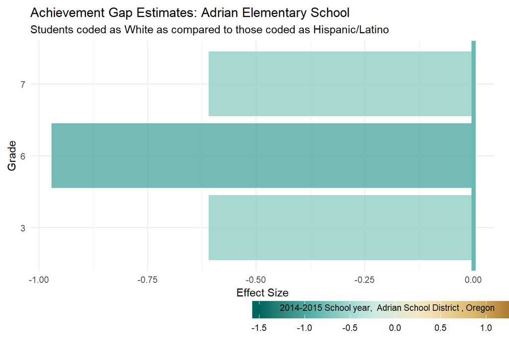

```r
plots <- t_es %>%
  mutate(plots = pmap(list(data = t_es$data,
                           school = t_es$school,
                           year = t_es$academic_year,
                           district = t_es$district),
                      function(data, school, year, district) {
       ggplot(data, aes(factor(grade_level), es)) +
       geom_col(aes(fill = es), alpha = .8)+
       geom_hline(yintercept = 0, color = "#68bab4", size = 2) +
       coord_flip() +
       scale_fill_distiller(palette = "BrBG", limits = c(-1.5, 1.5)) +
       theme_minimal() +
       theme(legend.position = c(.78,-.2),
             legend.direction = "horizontal",
             legend.key.width = unit(2, "cm"),
             plot.margin = margin(b = 1.75, r = 0.5, l = .25, t = .25, unit = "cm")) +
       labs(x = "Grade",
            y = "Effect Size",
            fill = "",
            title = paste("Achievement Gap Estimates:",school),
            subtitle = "Students coded as White as compared to those coded as Hispanic/Latino",
            caption = paste(year, "School year, ",district,", Oregon"))
  }))

plots$plots[[1]]
```

3. Save the plots into a “plots” directory. Make sure the file names are meaningful.

```r
#dir.create("plots")

#create file paths
files <- str_replace_all(tolower(plots$school), " ", "-")

paths <- here::here("plots", glue("{files}.png"))
paths

walk2(paths, plots$plots, ggsave,
      width = 9.5,
      height = 6.5,
      dpi = 500)
```

You don’t have to use a loop to create the file names (maybe give `{glue}` a try? Otherwise `paste` or `paste0` will work fine).

When working with the code, limit the number of plots you’re saving to, say, the first five to make sure it works before running it on all plots.